# Negative Projection Follow-up 2

Kathryn Denning

Originally June 2019 - Updated December 2019

# Introduction to study

This analysis uses data collected during the 2018 academic year from undergraduate students at the Univeristy of Oregon. This study aimed to answer the question of whether different politically polarizing contexts are more or less likely to lead people to see their political out-group as their opposite in regards to personality. We also included degree of in-group identification as a predictor, and conducted a second analysis using perceived polarization instead of issue polarization condition.

Variable names that might be confusing:

- **condition** : What issue participants were told the target disagreed with them on, these issues were designed to vary in polarization. Helmert contrasts were applied to this variable. *This variable was only inlcuded in Model 1.*
  - 1 = political candidate
  - 2 = racial discrimination
  - 3 = marijuana legalization
  - 4 = third party political system
- **ident_c** : how highly they identify with others who feel the same about them on the issue. This variable is mean centered.
  - Likert scale responses: 1 = *not at all identified* to 5 = *extremely identified*
- **self_c & targ** : Participants scores on the Big Five Inventory 2 Extra Small with additional honesty measures. They completed this for both themselves and the target. In order to assess projection, Self is included as a L1 predictor in the MLM. You can find the type of item the BFI2-XS with Honesty was measuring by looking at the variable titled **bfi2xsh_qtype**.
- **lib** : How much they thought the typical liberal would agree with their stance on the issue in the condition
- **cons** : How much they thought the typical conservative would agree with their stance on the issue in the condition
- **perceived_polar_c** : The difference between participant scores on lib and cons in order to assess how polarized people think that issue is societally. This predictor was mean centered. *This variable was only included in Model 2.*
- **check** : Manipulation check about whether or not they remembered the target’s stance on the issue correctly; 4 means they were incorrect.
- **opin** : Whether participants agreed or disgareed with the issue they were presented (e.g., Do you support marijuana legalization?)
  - 1 = Yes
  - 4 = No
  - 5 = Neither ** *This was an incorrect option given to the political candidate condition; people who responded this way were removed due to similiar answers not being available in the other conditions*

```
## [1] "png"
```

# Demographics

## Number of participants overall

```r
npf2_clean %>%
  select(sub_id) %>%
  unique() %>%
  nrow()
```

```
## [1] 334
```

## Number of participants per condition

```r
npf2_clean %>%
  select(sub_id, condition) %>%
  unique() %>%
  group_by(condition) %>%
  count()
```

```
## # A tibble: 4 x 2
## # Groups:   condition [4]
##   condition     n
##   <fct>     <int>
## 1 pol          64
## 2 race         96
## 3 weed         76
## 4 thirdpart    98
```

## Gender

```r
npf2_clean %>%
  select(sub_id, gender) %>%
  mutate(gender = recode(gender,
                         `1` = "Male",
                         `2` = "Female",
                         `3` = "Other")) %>%
  unique() %>%
  group_by(gender) %>%
  count()
```

```
## # A tibble: 3 x 2
## # Groups:   gender [3]
##   gender     n
##   <chr>  <int>
## 1 Female   243
## 2 Male      86
## 3 Other      5
```

## Race

```r
npf2_clean %>%
  select(sub_id, race) %>%
  mutate(race = recode(race,
                       `1` = "American Indian/Alaska Native",
                       `2` = "Asian",
                       `3` = "Black",
                       `4` = "Native Hawaiian/Pacific Islander",
                       `5` = "Caucasian",
                       `7` = "Latinx",
                       `8` = "Middle Eastern/North African",
                       `9` = "Prefer not to answer",
                       `10` = "Other")) %>%
  unique() %>%
  group_by(race) %>%
  count() %>%
  mutate(percent = n/334*100)
```

```
## # A tibble: 9 x 3
## # Groups:   race [9]
##   race                                 n percent
##   <chr>                            <int>   <dbl>
## 1 American Indian/Alaska Native        2   0.599
## 2 Asian                               46  13.8
## 3 Black                               14   4.19
## 4 Caucasian                          216  64.7
## 5 Latinx                              23   6.89
## 6 Middle Eastern/North African         2   0.599
## 7 Native Hawaiian/Pacific Islander     3   0.898
## 8 Other                               26   7.78
## 9 Prefer not to answer                 2   0.599
```

## Age

```r
npf2_clean %>%
  select(sub_id, age) %>%
  na.omit() %>%
  summarize(mean = mean(age),
            sd = sd(age))
```

```
## # A tibble: 1 x 2
##    mean    sd
##   <dbl> <dbl>
## 1  19.9  2.65
```

## Percent liberal

We chose to exclude people in the third party system condition because the issue is not necessarily framed as liberal or conservative issue.

```r
npf2_clean %>%
  select(sub_id, opin, condition) %>%
  filter(condition != "thirdpart") %>%
  na.omit() %>%
  unique() %>%
  group_by(opin) %>%
  count() %>%
  mutate(percent_lib = n/236*100)
```

```
## # A tibble: 2 x 3
## # Groups:   opin [2]
##    opin     n percent_lib
##   <dbl> <int>       <dbl>
## 1     1   195        82.6
## 2     4    41        17.4
```

## Histogram of distributions

### In-group identification

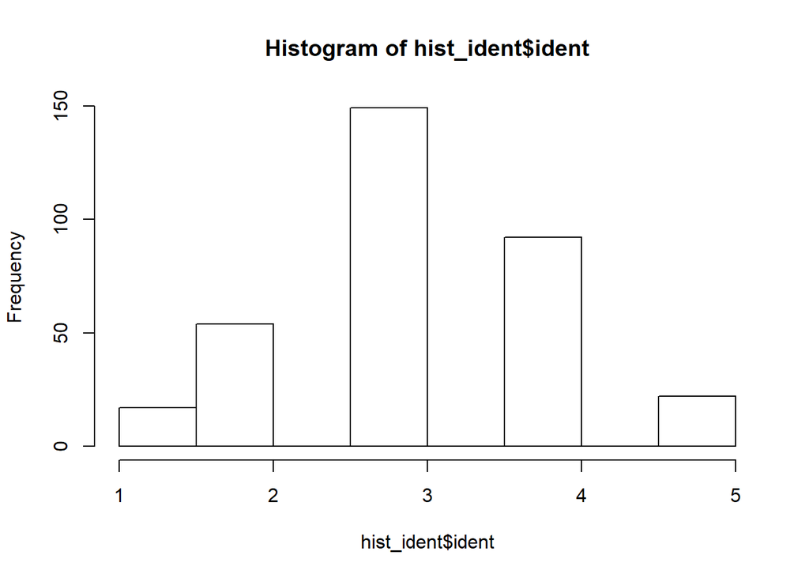

```r
hist_ident <- npf2_clean %>%
  select(sub_id, ident) %>%
  unique()
hist(hist_ident$ident)
```

### Perceived polarization

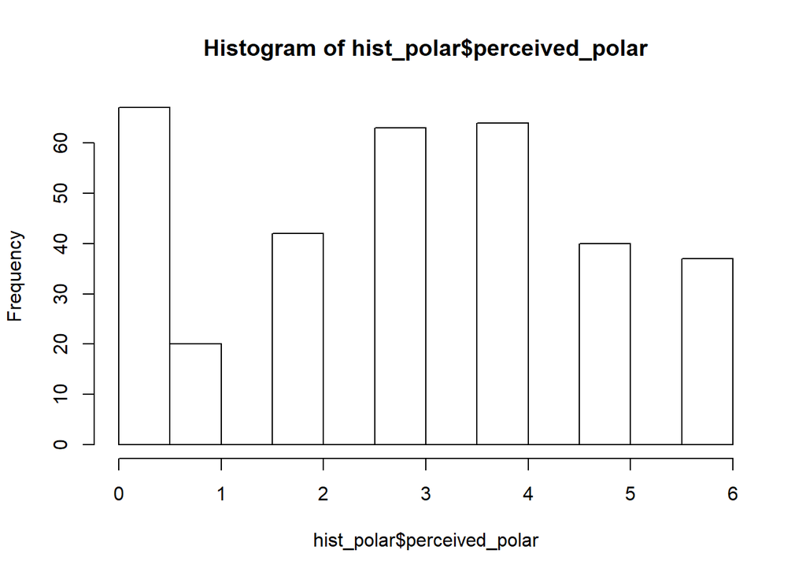

```r
hist_polar <- npf2_clean %>%
  select(sub_id, perceived_polar) %>%
  unique()
hist(hist_polar$perceived_polar)
```

## Mean and SD for BFI

### BFI for Self

```r
npf2_clean %>%
  select(sub_id, condition, self) %>%
  na.omit() %>%
  group_by(condition) %>%
  summarize(mean = mean(self),
            sd = sd(self))
```

```
## # A tibble: 4 x 3
##   condition  mean    sd
##   <fct>     <dbl> <dbl>
## 1 pol        3.38  1.21
## 2 race       3.40  1.18
## 3 weed       3.37  1.20
## 4 thirdpart  3.50  1.17
```

### BFI for Target

```r
npf2_clean %>%
  select(sub_id, condition, targ) %>%
  na.omit() %>%
  group_by(condition) %>%
  summarize(mean = mean(targ),
            sd = sd(targ))
```

```
## # A tibble: 4 x 3
##   condition  mean    sd
##   <fct>     <dbl> <dbl>
## 1 pol        3.09  1.08
## 2 race       3.13  1.09
## 3 weed       3.31  1.11
## 4 thirdpart  3.19  1.02
```

## Mean and SD for in-group identification

```r
npf2_clean %>%
  select(sub_id, condition, ident) %>%
  na.omit() %>%
  group_by(condition) %>%
  summarize(mean = mean(ident),
            sd = sd(ident))
```

```
## # A tibble: 4 x 3
##   condition  mean    sd
##   <fct>     <dbl> <dbl>
## 1 pol        3.30 0.785
## 2 race       3.41 0.731
## 3 weed       3.30 0.975
## 4 thirdpart  2.66 1.01
```

# Model 1: Projection predicted by condition

## Contrast codes

```r
model_data <- npf2_clean %>%
  select(targ, self_c, ident_c, condition, sub_id, perceived_polar_c, perceived_polar) %>%
  na.omit()
levels(model_data$condition)
```

```
## [1] "pol"       "race"      "weed"      "thirdpart"
```

```r
contrasts(model_data$condition) <- "contr.helmert"
contrasts(model_data$condition)
```

```
##           [,1] [,2] [,3]
## pol         -1   -1   -1
## race         1   -1   -1
## weed         0    2   -1
## thirdpart    0    0    3
```

## Results

For a result on projection, the main effect must include BFI the self (self_c) interacting with that variable.

```r
#Model with random slopes for BFI (aka more conservative model)
model1_randomslopes <- lmer(targ ~ self_c*ident_c*condition + (self_c|sub_id),
                            data = model_data)

tab_model(model1_randomslopes,
          title = "MLM predicting projection with random slopes and helmert contrasts",
          dv.labels = "BFI responses for target",
          pred.labels = c("(Intercept)",
                          "BFI responses for self",
                          "Identification",
                          "Condition 1: Politics vs Race",
                          "Condition 2: Politics, Race vs Marijuana",
                          "Condition 3: Politics, Race, Marijuana vs Third Party",
                          "BFI responses for self:Identification",
                          "BFI responses for self:Condition 1",
                          "BFI responses for self:Condition 2",
                          "BFI responses for self:Condition 3",
                          "Identification:Conditon 1",
                          "Identification:Condition 2",
                          "Identification:Condition 3",
                          "BFI responses for self:Identification:Condition 1",
                          "BFI responses for self:Identification:Condition 2",
                          "BFI responses for self:Identification:Condition 3"))
```

MLM predicting projection with random slopes and helmert contrasts

|  | BFI responses for target |  |  |
| --- | --- | --- | --- |
| Predictors | Estimates | CI | p |
| (Intercept) | 3.19 | 3.15 – 3.23 | **<0.001** |
| BFI responses for self | 0.00 | -0.03 – 0.04 | 0.941 |
| Identification | -0.09 | -0.14 – -0.05 | **<0.001** |
| Condition 1: Politics vs Race | 0.03 | -0.03 – 0.08 | 0.336 |
| Condition 2: Politics, Race vs Marijuana | 0.06 | 0.03 – 0.10 | **<0.001** |
| Condition 3: Politics, Race, Marijuana vs Third Party | -0.01 | -0.03 – 0.01 | 0.425 |
| BFI responses for self:Identification | -0.05 | -0.09 – -0.02 | **0.006** |
| BFI responses for self:Condition 1 | -0.04 | -0.09 – 0.01 | 0.152 |
| BFI responses for self:Condition 2 | 0.04 | 0.01 – 0.07 | **0.007** |
| BFI responses for self:Condition 3 | 0.01 | -0.01 – 0.03 | 0.475 |
| Identification:Conditon 1 | -0.01 | -0.08 – 0.06 | 0.753 |
| Identification:Condition 2 | 0.01 | -0.02 – 0.05 | 0.454 |
| Identification:Condition 3 | 0.01 | -0.01 – 0.04 | 0.208 |
| BFI responses for self:Identification:Condition 1 | 0.04 | -0.02 – 0.11 | 0.159 |
| BFI responses for self:Identification:Condition 2 | -0.01 | -0.04 – 0.02 | 0.694 |
| BFI responses for self:Identification:Condition 3 | 0.01 | -0.01 – 0.03 | 0.255 |
| Random Effects |  |  |  |
| σ<sup>2</sup> | 1.02 |  |  |
| τ<sub>00</sub> <sub>sub_id</sub> | 0.06 |  |  |
| τ<sub>11</sub> <sub>sub_id.self_c</sub> | 0.05 |  |  |
| ρ<sub>01</sub> <sub>sub_id</sub> | 0.53 |  |  |
| ICC | 0.11 |  |  |
| N <sub>sub_id</sub> | 333 |  |  |
| Observations | 6305 |  |  |
| Marginal R<sup>2</sup> / Conditional R<sup>2</sup> | 0.019 / 0.122 |  |  |

## Plots for Model 1

### Main effect of in-group identification on projection

```r
#Getting stats for plot
describe(model_data$ident_c)
```

```
##    vars    n mean   sd median trimmed  mad   min  max range  skew kurtosis   se
## X1    1 6305 0.08 0.94  -0.06     0.1 1.48 -2.06 1.94     4 -0.19    -0.07 0.01
```

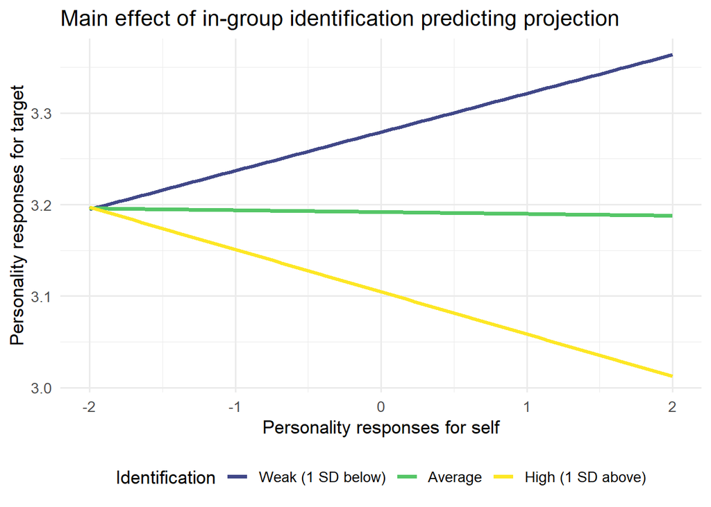

```r
effects_data <- as_tibble(effect(term = "self_c:ident_c",
                                 xlevels = list(ident_c = c(-0.94, 0, 0.94)),
                                 mod = model1_randomslopes), na.rm = TRUE)

effects_data$Identification <-as.factor(effects_data$ident_c)

# Color plot for conference presentation
ggplot(effects_data, aes(self_c, fit, color = Identification)) +
  geom_smooth(method = "lm",
              se = FALSE,
              size = 1.25,
              alpha = .3,
              aes(color = Identification)) +
  scale_color_manual(breaks = c(-0.94, 0, 0.94),
                     labels = c ("Weak (1 SD below)",
                                  "Average",
                                  "High (1 SD above)"),
                     values = c('#404788FF',
                               '#55C667FF',
                               '#FDE725FF')) +
  theme_minimal(base_size = 13) +
  theme(legend.position = "bottom") +
  labs(title = "Main effect of in-group identification predicting projection",
       x = "Personality responses for self",
       y = "Personality responses for target")
```

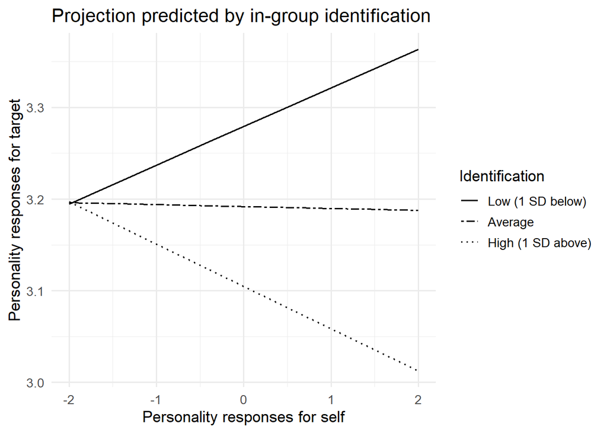

```r
# Black and white plot for publication
ggplot(effects_data, aes(self_c, fit, group = Identification)) +
  geom_line(aes(linetype = Identification), size = .7) +
  scale_linetype_manual("Identification",
                       breaks = c(-0.94, 0, 0.94),
                       labels = c ("Low (1 SD below)",
                                  "Average",
                                  "High (1 SD above)"),
                        values = c("solid",
                                   "twodash",
                                   "dotted")) +
  theme_minimal(base_size = 13) +
  labs(title = "Projection predicted by in-group identification",
       x = "Personality responses for self",
       y = "Personality responses for target")
```

```r
ggsave("figure7.png", device = "png", type = "cairo", width = 6, height = 4)
```

### Main effect of condition on projection

```r
# Set-up stats for plot
levels(model_data$condition)
```

```
## [1] "pol"       "race"      "weed"      "thirdpart"
```

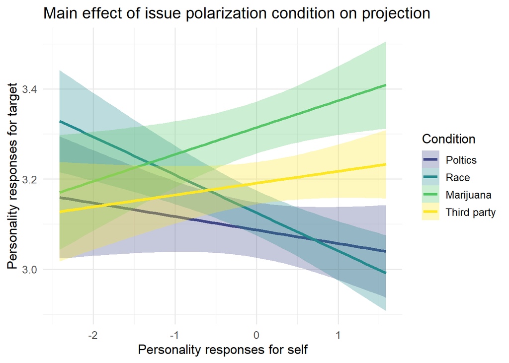

```r
cond_recode_plot <- model_data %>%
  mutate(Condition = recode(condition,
                            `pol` = "Poltics",
                            `race` = "Race",
                            `weed` = "Marijuana",
                            `thirdpart` = "Third party"))

# Color plot for conference presentation
ggplot(cond_recode_plot, aes(self_c, targ)) +
  geom_smooth(method = "lm", se = TRUE, size = 1.25, alpha = .3, aes(color = Condition, fill = Condition)) +
  theme_minimal(base_size = 13) +
  scale_color_manual(values = c('#404788FF',
                               '#238A8DFF',
                               '#55C667FF',
                               '#FDE725FF')) +
  scale_fill_manual(values = c('#404788FF',
                               '#238A8DFF',
                               '#55C667FF',
                               '#FDE725FF')) +
  labs(title = "Main effect of issue polarization condition on projection",
       x = "Personality responses for self",
       y = "Personality responses for target")
```

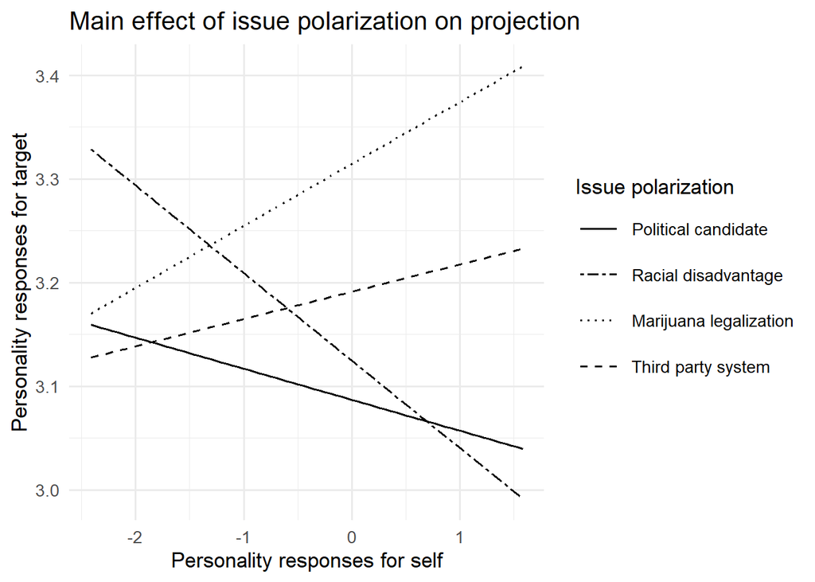

```r
# Black and white plot for publication
ggplot(cond_recode_plot, aes(self_c, targ, group = Condition)) +
  geom_smooth(method = "lm",
              se = FALSE,
              size = .7,
              colour = "black",
              aes(linetype = Condition)) +
  theme_minimal(base_size = 13) +
  theme(legend.key.size = unit(1, "cm")) +
  scale_linetype_manual("Issue polarization",
                        labels = c("Political candidate",
                                  "Racial disadvantage",
                                  "Marijuana legalization",
                                  "Third party system"),
                       values = c("solid",
                                   "twodash",
                                   "dotted",
                                   "dashed")) +
  labs(title = "Main effect of issue polarization on projection",
       x = "Personality responses for self",
       y = "Personality responses for target")
```

# Model 2: Projection predicted by perceived polarization

```r
# Model
model2_randomslopes <- lmer(targ ~ self_c*ident_c*perceived_polar_c +
                              (self_c|sub_id),
                            data = model_data)

# Results
tab_model(model2_randomslopes, title = "Model 2 with random slopes",
          dv.labels = "BFI responses for target",
          pred.labels = c("(Intercept)",
                          "BFI for self",
                          "Identification",
                          "Perceived polarization",
                          "BFI for self:Identification",
                          "BFI for self:Perceived polarization",
                          "Identification:Perceived polarization",
                          "BFI for self:Identification:Perceived polarization"))
```

Model 2 with random slopes

|  | BFI responses for target |  |  |
| --- | --- | --- | --- |
| Predictors | Estimates | CI | p |
| (Intercept) | 3.19 | 3.15 – 3.23 | **<0.001** |
| BFI for self | 0.01 | -0.03 – 0.04 | 0.761 |
| Identification | -0.09 | -0.13 – -0.04 | **<0.001** |
| Perceived polarization | 0.01 | -0.01 – 0.03 | 0.232 |
| BFI for self:Identification | -0.03 | -0.07 – 0.01 | 0.091 |
| BFI for self:Perceived polarization | -0.02 | -0.04 – 0.00 | 0.059 |
| Identification:Perceived polarization | -0.01 | -0.03 – 0.01 | 0.533 |
| BFI for self:Identification:Perceived polarization | -0.01 | -0.03 – 0.01 | 0.343 |
| Random Effects |  |  |  |
| σ<sup>2</sup> | 1.02 |  |  |
| τ<sub>00</sub> <sub>sub_id</sub> | 0.06 |  |  |
| τ<sub>11</sub> <sub>sub_id.self_c</sub> | 0.05 |  |  |
| ρ<sub>01</sub> <sub>sub_id</sub> | 0.55 |  |  |
| ICC | 0.11 |  |  |
| N <sub>sub_id</sub> | 333 |  |  |
| Observations | 6305 |  |  |
| Marginal R<sup>2</sup> / Conditional R<sup>2</sup> | 0.010 / 0.119 |  |  |

## Plots for Model 2

### Main effect of in-group identification on projection (trending)

```r
#Getting stats for plot
describe(model_data$ident_c)
```

```
##    vars    n mean   sd median trimmed  mad   min  max range  skew kurtosis   se
## X1    1 6305 0.08 0.94  -0.06     0.1 1.48 -2.06 1.94     4 -0.19    -0.07 0.01
```

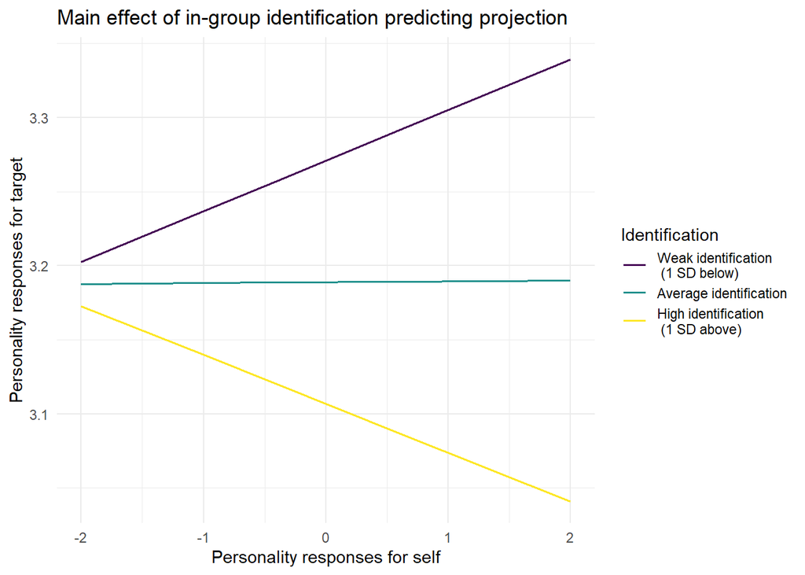

```r
effects_data2 <- as_tibble(effect(term = "self_c:ident_c",
                                 xlevels = list(ident_c = c(-0.94, 0, 0.94)),
                                 mod = model2_randomslopes), na.rm = TRUE)

effects_data2$Identification <-as.factor(effects_data2$ident_c)

# Color plot
ggplot(effects_data2, aes(self_c, fit)) +
  geom_line(size = .7, aes(color = Identification)) +
  scale_color_viridis_d(breaks = c(-0.94, 0, 0.94),
                       labels = c ("Weak identification \n (1 SD below)",
                                  "Average identification",
                                  "High identification \n (1 SD above)")) +
  theme_minimal() +
  labs(title = "Main effect of in-group identification predicting projection",
       x = "Personality responses for self",
       y = "Personality responses for target")
```

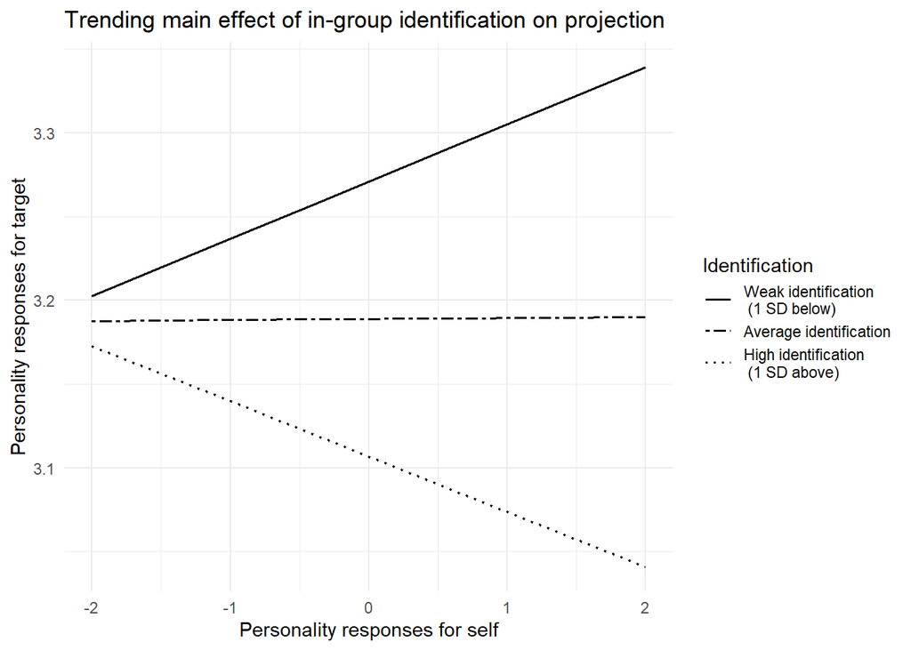

```r
ggplot(effects_data2, aes(self_c, fit, group = Identification)) +
  geom_line(size = .7, aes(linetype = Identification)) +
  scale_linetype_manual("Identification",
                       breaks = c(-0.94, 0, 0.94),
                       labels = c ("Weak identification \n (1 SD below)",
                                  "Average identification",
                                  "High identification \n (1 SD above)"),
                        values = c("solid",
                                   "twodash",
                                   "dotted")) +
  theme_minimal() +
  labs(title = "Trending main effect of in-group identification on projection",
       x = "Personality responses for self",
       y = "Personality responses for target")
```

### Main effect of perceived polarization on projection (trending)

```r
# Getting stats for plot
describe(model_data$perceived_polar)
```

```
##    vars    n mean   sd median trimmed  mad min max range  skew kurtosis   se
## X1    1 6305 2.92 1.96      3     2.9 1.48   0   6     6 -0.12     -1.1 0.02
```

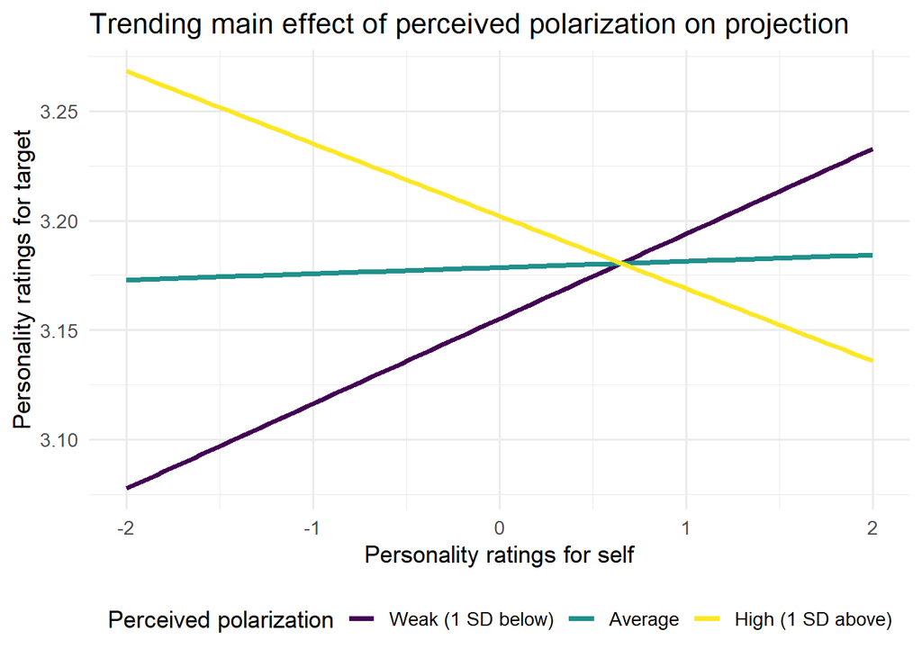

```r
effects_data3 <- as_tibble(effect(term = "self_c:perceived_polar_c",
                                 xlevels = list(perceived_polar_c = c(-1.96,
                                                                      0,
                                                                      1.96)),
                                 mod = model2_randomslopes), na.rm = TRUE)

effects_data3$perceived_polar <-as.factor(effects_data3$perceived_polar_c)

# Color plot for conference presentation
ggplot(effects_data3, aes(self_c, fit)) +
  geom_smooth(method = "lm",
              se = FALSE,
              size = 1.25,
              aes(color = perceived_polar)) +
  scale_color_viridis_d("Perceived polarization",
                       breaks = c(-1.96, 0, 1.96),
                       labels = c ("Weak (1 SD below)",
                                  "Average",
                                  "High (1 SD above)")) +
  theme_minimal(base_size = 13) +
  theme(legend.position = "bottom") +
  labs(title = "Trending main effect of perceived polarization on projection",
       x = "Personality ratings for self",
       y = "Personality ratings for target")
```

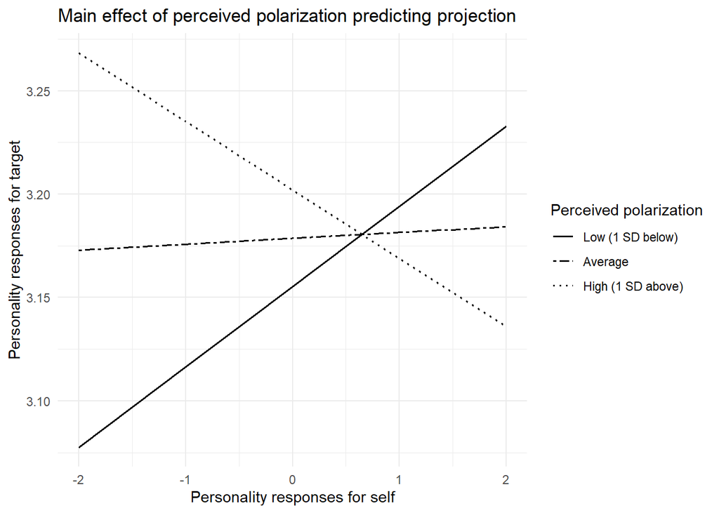

```r
# Black and white plot for publication
ggplot(effects_data3, aes(self_c, fit)) +
  geom_line(size = .7,
              colour = "black",
              aes(linetype = perceived_polar)) +
  scale_linetype_manual("Perceived polarization",
                        breaks = c(-1.96, 0, 1.96),
                       labels = c ("Low (1 SD below)",
                                  "Average",
                                  "High (1 SD above)"),
                        values = c("solid",
                                   "twodash",
                                   "dotted")) +
  theme_minimal() +
  labs(title = "Main effect of perceived polarization predicting projection",
       x = "Personality responses for self",
       y = "Personality responses for target")
```

# Perceived polarization as outcome predicted by condition

## Descriptives

```r
mean_perceivedpol <- model_data %>%
  select(sub_id, condition, perceived_polar) %>%
   mutate(condition = recode(condition,
                            `pol` = "Poltical candidate",
                            `race` = "Racial disadvantage",
                            `weed` = "Marijuana legalization",
                            `thirdpart` = "Third party system")) %>%
  group_by(condition) %>%
  mutate(mean_percbycond = mean(perceived_polar)) %>%
  summarise(mean = mean(mean_percbycond),
            sd = sd(perceived_polar))
mean_perceivedpol
```

```
## # A tibble: 4 x 3
##   condition               mean    sd
##   <fct>                  <dbl> <dbl>
## 1 Poltical candidate      3.68  1.79
## 2 Racial disadvantage     3.18  1.96
## 3 Marijuana legalization  3.34  1.75
## 4 Third party system      1.84  1.77
```

## Results

```r
# Contrast codes
contrasts(npf2_clean$condition) <- "contr.helmert"
contrasts(npf2_clean$condition)
```

```
##           [,1] [,2] [,3]
## pol         -1   -1   -1
## race         1   -1   -1
## weed         0    2   -1
## thirdpart    0    0    3
```

```r
# Model
polar_outcome <- lm(perceived_polar ~ condition, data = npf2_clean)
summary(polar_outcome)
```

```
##
## Call:
## lm(formula = perceived_polar ~ condition, data = npf2_clean)
##
## Residuals:
##    Min     1Q Median     3Q    Max
## -3.682 -1.682  0.161  1.318  4.161
##
## Coefficients:
##             Estimate Std. Error t value Pr(>|t|)
## (Intercept)  3.01012    0.02338 128.741  < 2e-16 ***
## condition1  -0.25067    0.03402  -7.368 1.96e-13 ***
## condition2  -0.03115    0.01966  -1.584    0.113
## condition3  -0.39038    0.01267 -30.812  < 2e-16 ***
## ---
## Signif. codes:  0 '***' 0.001 '**' 0.01 '*' 0.05 '.' 0.1 ' ' 1
##
## Residual standard error: 1.826 on 6301 degrees of freedom
##   (19 observations deleted due to missingness)
## Multiple R-squared:  0.1335, Adjusted R-squared:  0.1331
## F-statistic: 323.7 on 3 and 6301 DF,  p-value: < 2.2e-16
```

```r
confint(polar_outcome)
```

```
##                   2.5 %       97.5 %
## (Intercept)  2.96428326  3.055953644
## condition1  -0.31736797 -0.183977430
## condition2  -0.06968438  0.007393574
## condition3  -0.41521366 -0.365540234
```

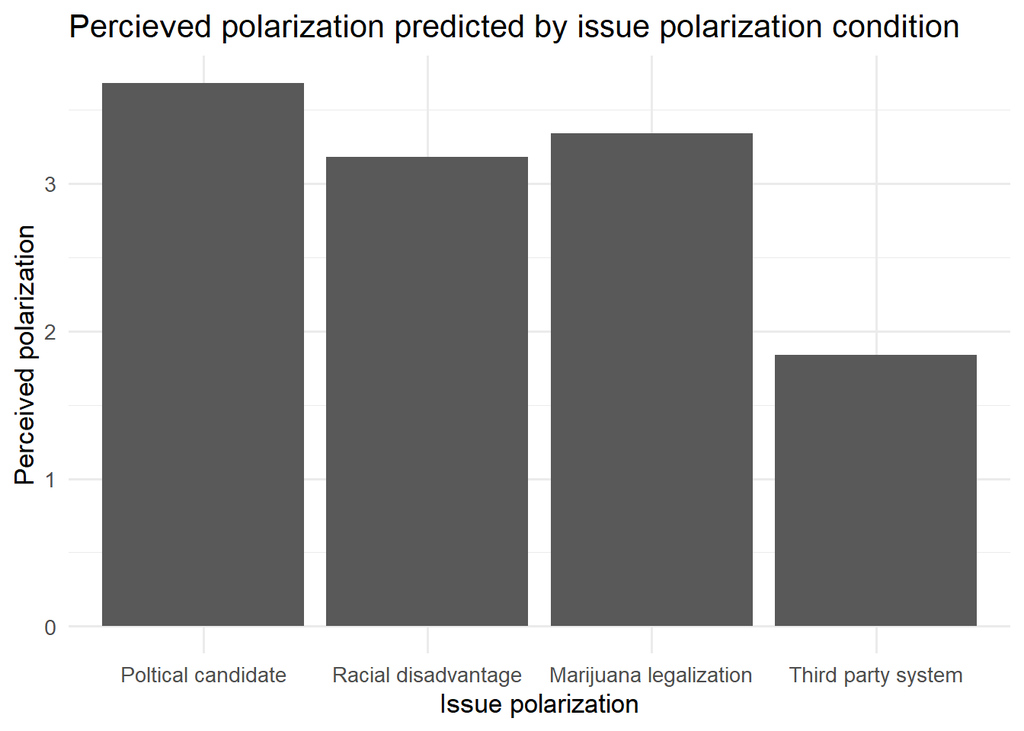

```r
ggplot(mean_perceivedpol, aes(x = condition, y = mean)) +
  geom_bar(stat = "identity") +
  theme(legend.position = "none") +
  scale_colour_grey() +
  theme_minimal(base_size = 13) +
  labs(title = "Percieved polarization predicted by issue polarization condition",
       x = "Issue polarization",
       y = "Perceived polarization") +
  theme(legend.position = "none")
```